# Turizmas

Auksė Simanavičiūtė

6/17/2019

## KONTEKSTAS

Turizmas svarbus tuo, kad jis kelia šalies ekonomiką, padeda atsirasti naujoms darbo vietoms, taip pat leidžia kurti šalies įvaizdį. Turizmas neabejotinai suteikia didžiulę ekonominę naudą šaliai, darydamas tiesioginę įtaką pramonės šakoms arba netiesioginę per turizmo išlaidas. Tačiau ekonominė nauda nėra vienintelis turizmo privalumas, apie kurį galime diskutuoti. Dėmesio vertas bei labai svarbus yra ir sociokultūrinis turizmo poveikis. Turizmas didina socialinę integraciją, skatina žmonių pasaulio suvokimo, akiračio plėtrą, ugdo pilietines vertybes, toleranciją. Per turizmą žmonės turi galimybę susipažinti su naujomis kultūromis bei plėsti pažinčių ratą.

## DARBO TIKSLAS

Turizmas kiekvienai šaliai yra svarbus ne tik atvykstamasis, bet ir vietinis, bei išvykstamasis. Todėl šiame rašto darbe ir stengsiuosi parodyti, kokie skirtingi statistikos duomenys vyrauja kiekvienai turistų grupei Lietuvoje, aptarti jų pokyčių galimybes.

## LIETUVOS RESPUBLIKOS TURISTŲ TIPAI

Vietiniai turistai renkasi labiau pažinti Lietuvą ir keliauja kelioms dienoms į įvairius savo gimtos šalies kampelius. Vietiniai turistai, gyvenantys didžiuosiuose miestuose, norėdami pabėgti nuo jų šurmulio, renkasi važiuoti į kaimus, sodybas, mažesnius miestelius. Dažai apsistoja prie ežerų, jie ieško ramybės. Priešingai elgiasi kaimelių, mažesnių miestelių žmonės. Jie šiuo atveju ieško šurmulio arba nori pasikultūrinti. Kaip žinia teatrai, muziejai, koncertai, kino salės yra tik didžiuosiuose miestuose. Taip pat tėvai lankydami savo studentus vaikus, kurie studijuoja miestuose, tampa vietinių turistų skaičių dalimi. Šiuos žmonės į miestus skatina atvykti ir naujai atidaromi, restauruoti objektai: muziejai, bažnyčios, modernūs pastatai ir kitos lankomos vietos. Kiekvienam išsilavinusiam Lietuviui svarbu pažinti savo šalį, o ją geriausiai pažinsi tik keliaudamas ir lankydamas istorines jos vietas, bei pamatydamas archajiškus objektus disponuojamus muziejuose.

Gali būti atvykę turistai, užsieniečiai, kurie dažniausiai renkasi įžymiausias Lietuvos vietas, kad prisiliestų prie lietuviškos kultūros. Atvykę turistai turi tendenciją rinktis kurortinius miestus ypač tuos, kurie siūlo sveikatingumo paslaugas ir SPA – Birštonas, Druskininkai. Vasara turistai linkę rinktis Palangą, Nidą, Šventają, dėl galimybės būti arti Baltijos jūros. Žinoma, Lietuvos sotinė – Vilnius, visais metų laikais yra populiariausias turistų pasirenkamas miestas Lietuvoje. Vilnius, Kaunas ir Palanga yra patogus turistų pasirinkimas ir dėl juose esančių oro uostų. Į Lietuvą žmonės turi galimybę atvykti ir Klaipėdos uosto pagalba. Turistus vilioja tai, kad Lietuva yra Europos centras. Taip pat šalyje yra unikalių objektų, neegzistuojančių niekur kitur pasaulyje, kaip pvz.: Kryžių kalnas (Šiauliai), Raganų kalnas (Juodkrantė). Žinoma, Lietuva gali pasigirti gražiu kraštovaizdžiu, turistams iš tokių šalių kaip Japonija , kur miestų plėtimas dėl didelio gyventojų skaičiaus naikina jų gamtą. Didžiajai daliai atvykstančių turistų, ypač tiems iš Vakarų, Lietuva patraukli dėl mažų kainų, kurios vietiniams turistams, gali pasirodyti didelės.

Taip pat yra ir išvykusių Lietuvos turistų, kurie važiuoja į kitas šalis plėsti savo akiračio, pamatyti kitus papročius, kurti naują pažinčių ratą. Į kitas šalis žmonės išvažiuoja komandiruotėms, kuriose užsimezga nauji verslo ryšiai. Studijuojantiems žmonėms yra sudarytos puikios sąlygos praplėsti savo žinias užsienio šalyse, studijuojant ir tuo pačiu susipažįstant su nauja šalimi - jos kultūra, papročiais, jos istorija. Taip pat sportuojant, užsiimant meninę veikla yra tarptautinės galimybės išvykti iš savo šalies, taip pasirodant kitur ir pakeliaujant naujoje šalyje. Lietuvos turistai dažnai renkasi kaimynines šalis dėl ekonominių priežasčių, pavyzdžiui dėl mažų kainų. Tokių būdu, jie apsiperka ir išnaudoja tą progą susipažinimui su svetima šalimi. Dar viena priežastis trumpam pakeisti aplinką yra emigravusių giminių lankymas, tokių būdų viena ar kelis kartus per metus žmonės tampa išvykstančių turistų vienetais. Viena iš populiariausių išvykstamojo turizmo priežasčių yra klimatas. Žiema žmonės dažnai nori atitrūkti nuo šalčio, tad renkasi šalis garsėjančias geromis oro sąlygomis, kaip aukšta temperatūra, saulėtos dienos. Taip pat juos vilioja tokie kelionių paketai, kaip “Viskas įskaičiuota”, kuris dažnai pasitaiko Turkijoje, Egipte. Vietiniai gyventojai dažnai nepasitenkina savo šalyje esančiais paplūdimiais ir kainų pasiūla, tad renkasi turistauti renkasi užsienio valstybes. Tačiau kitiems, adrenalino fanatikams, Lietuvoje trūksta sąlygų. Slidininkams – žiema yra per trumpa, ir trūksta kalnuotų vietovių. Nardytojams Baltijos jūra yra nepalanki jų hobiui. Taip pat už Lietuvos sienų yra daugiau ir įvairesnių gamtos reiškinių. Dar išvykusiems turistams priklauso žmonių grupė, kurie reguliariai keliauja tiesiog dėl pramogos, kaupdami įspūdžius, istorijas. Šie žmones tą sukauptą medžiagą perteikia įvairiai auditorijai skirtingais būdais: knygose, podcast’uose, blog’uose, socialiniuose tinkluose, televizijų laidose. Išvykstamasis turizmas populiarus dėl kelių veiksnių. Socialine prasme, dėl naujų pažinčių, kurios ateityje gali padėti verslo plėtrai, pasaulio pažinimui. Ekonomine prasme, idėjų parsivežimas iš svetimų šalių, kurios įkvepia naujų produktų kūrimui, naujų investuotojų pritraukimui.

## TURISTŲ SKAIČIUS

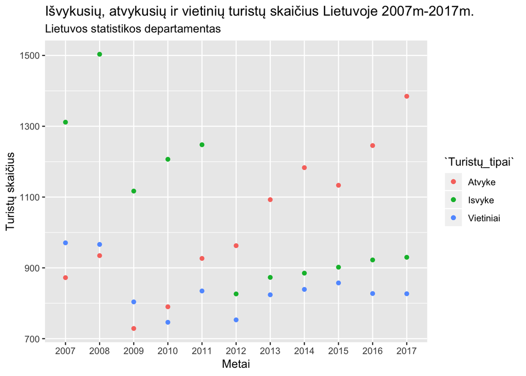

Tačiau išvykusiu ir atvykusių turistų skaičius yra tikrai netolygus. Kalbant apie išvykusius turistus jie lyderiauja 2007-2011m. Tačiau jos augimas nėra nuoseklus, nes 2007-2008m. ji auga sparčiai ir 2008m. pasiekia bendra turistų skaičiaus viršūnę Lietuvoje šiuo laikotarpiu. O 2009m. pastebime stiprų išvykstančių skaičių nukritimą, tokią statistiką galėjo įtakoti tuo metu vyraujanti pasaulinė krizė, infliacija. To sekoje 2010m. Lietuvoje smarkiai išaugo emigraciją ir žmonės Lietuvoje keliavo aplankyti savo artimųjų į kitas šalis, taip galimai tapdami dalimi išvykstančių turistų. Tačiau galime pastebėti drastišką išvykstančių turistų pokyti 2012m. Viena iš priežasčių, kurią galiu numanyti, kad žlugo “Snoras” bankas ir žmonės neteko daug pinigų. Išvykstančių turistų skaičius nebėra aukštumoje kaip buvo prieš krizės laikotarpį. Jis tapo tolygiai augantis.

Atvykusiu turistų skaičius 2007m. nebuvo dominuojantis tarp bendrų Lietuvos turistų duomenų, tačiau jis buvo augantis. Tačiau 2009m. kaip ir visų kitų esančių turistų grupių, skaičius drastiškai sumažėjo. Ir tai taipogi greičiausiai įtakojo pasaulinė krizė. Gera žinia, kad 2011m. atvykstančių turistų skaičius smarkiai šoktelėjo ir be to tuo metu Lietuvoje turistų srautai augo sparčiausiai Europoje. (citata is TURIZMO VALDYMO TOBULINIMO PERSPEKTYVOS LIETUVOJE: NACIONALINIO IR SAVIVALDYBIŲ LYGMENŲ SĄVEIKA). 2012-2015m. atvykstančių turistų skaičius lyderiauja grafike. Prie to galėjo prisidėti turizmo programos: Nacionalinė turizmo plėtros 2010-2013m. ir 2014-2020m. (citata seimo) 2015m. pastebimas nesmarkus atvykstančių turistų sumažėjimas. Tai galėjo lemti 2015m. Lietuvos įstojimas į eurozoną. Sumažėjimas nebuvo didelis, nes daugumai Europos šalių tai buvo tik privalumas, tačiau kitoms šalims - sukėlė nepatogių pokyčių. Euro įvedimas įtakojo kainų kilimą. Tačiau jų įtaką infliacijai buvo nedidelė ir laikina dėl to 2016m. atvykstančių turistų skaičius atsistato ir sparčiai didėja. (lietuvos bankas)

## TURISTŲ IŠLAIDOS

```r
if(!require(eurostat)) install.packages("eurostat") ; require(eurostat)
if(!require(tidyverse)) install.packages("tidyverse") ; require(tidyverse)
if(!require(rsdmx)) install.packages("rsdmx") ; require(rsdmx)
if(!require(openxlsx)) install.packages("openxlsx") ; require(openxlsx)
if(!require(dplyr)) install.packages("dplyr") ; require(dplyr)
if(!require(ggplot2)) install.packages("ggplot2") ; require(ggplot2)
if(!require(tidyr)) install.packages("tidyr") ; require(tidyr)
if(!require(knitr)) install.packages("knitr") ; require(knitr)
#Duomenu failo atsiuntimas ir issaugojimas
# Sukursiu duomenu lenteles visu grupiu turistu islaidu skaiciu
islaidos_vtn <- readSDMX(providerId ="LSD",
                      resource = "data",
                      flowRef = "S8R495_M4091505_2",
                      dsd= TRUE)
```

[output not shown]

[output not shown]

[output not shown]

[output not shown]

[output not shown]

```r
islaidos_vtn <- as.data.frame(islaidos_vtn)
islaidos_vtn <- islaidos_vtn %>% filter(LAIKOTARPIS > "2006-01-01")

islaidos_atvk <- readSDMX(providerId ="LSD",
                         resource = "data",
                         flowRef = "S8R694_M4091301_3",
                         dsd= TRUE)
```

[output not shown]

[output not shown]

[output not shown]

[output not shown]

[output not shown]

```r
islaidos_atvk<- as.data.frame(islaidos_atvk)
islaidos_atvk <- islaidos_atvk %>% filter(LAIKOTARPIS > "2006-01-01")

islaidos_isvk <- readSDMX(providerId ="LSD",
                          resource = "data",
                          flowRef = "S8R706_M4091101_3",
                          dsd= TRUE)
```

[output not shown]

[output not shown]

[output not shown]

[output not shown]

[output not shown]

```r
islaidos_isvk<- as.data.frame(islaidos_isvk)
islaidos_isvk <- islaidos_isvk %>% filter(LAIKOTARPIS > "2006-01-01")

dt<- data.frame(VIETINIAI, ISVYKE, ATVYKE)
#-------
# Sukursiu duomenu lenteles visu grupiu turistu dienos islaidu sumai
vidut_dienos_vtn <- readSDMX(providerId ="LSD",
                           resource = "data",
                           flowRef = "S8R501_M4091505_3",
                           dsd= TRUE)
```

[output not shown]

[output not shown]

[output not shown]

[output not shown]

[output not shown]

```r
vidut_dienos_vtn<- as.data.frame(vidut_dienos_vtn)
vidut_dienos_vtn <- vidut_dienos_vtn %>% filter(LAIKOTARPIS > "2006-01-01")


vidut_dienos_atvk <- readSDMX(providerId ="LSD",
                             resource = "data",
                             flowRef = "S8R698_M4091301_2",
                             dsd= TRUE)
```

[output not shown]

[output not shown]

[output not shown]

[output not shown]

[output not shown]

```r
vidut_dienos_atvk<- as.data.frame(vidut_dienos_atvk)
vidut_dienos_atvk <- vidut_dienos_atvk %>% filter(LAIKOTARPIS > "2006-01-01")


vidut_dienos_isvk <- readSDMX(providerId ="LSD",
                              resource = "data",
                              flowRef = "S8R710_M4091101_2",
                              dsd= TRUE)
```

[output not shown]

[output not shown]

[output not shown]

[output not shown]

[output not shown]

```r
vidut_dienos_isvk<- as.data.frame(vidut_dienos_isvk)
vidut_dienos_isvk <- vidut_dienos_isvk %>% filter(LAIKOTARPIS > "2006-01-01")

################################
#Sukursiu duomenu lenteles visu grupiu turistu vienos keliones vidutiniu islaidu sumai
vidut_keliones_vtn <- readSDMX(providerId ="LSD",
                              resource = "data",
                              flowRef = "S8R502_M4091505_3",
                              dsd= TRUE)
```

[output not shown]

[output not shown]

[output not shown]

[output not shown]

[output not shown]

```r
vidut_keliones_vtn<- as.data.frame(vidut_keliones_vtn)
vidut_keliones_vtn <- vidut_keliones_vtn %>% filter(LAIKOTARPIS > "2006-01-01")

vidut_keliones_atvk <- readSDMX(providerId ="LSD",
                               resource = "data",
                               flowRef = "S8R697_M4091301_2",
                               dsd= TRUE)
```

[output not shown]

[output not shown]

[output not shown]

[output not shown]

[output not shown]

```r
vidut_keliones_atvk<- as.data.frame(vidut_keliones_atvk)
vidut_keliones_atvk<- vidut_keliones_atvk %>% filter(LAIKOTARPIS > "2006-01-01")

vidut_keliones_isvk <- readSDMX(providerId ="LSD",
                                resource = "data",
                                flowRef = "S8R711_M4091101_2",
                                dsd= TRUE)
```

[output not shown]

[output not shown]

[output not shown]

[output not shown]

[output not shown]

```r
vidut_keliones_isvk <- as.data.frame(vidut_keliones_isvk)
vidut_keliones_isvk <- vidut_keliones_isvk %>% filter(LAIKOTARPIS > "2006-01-01")
```